# Лабораторная работа № 3

Настройка DHCP-сервера

Павличенко Родион Андреевич

1132246838@rudn.ru

Российский университет дружбы народов им. Патриса Лумумбы

2026-09-17

# Информация

## Докладчик

- Павличенко Родион Андреевич
- Студент
- Группа НПИбд-02-24
- Российский университет дружбы народов им. Патриса Лумумбы
- 1132246838@rudn.ru

# Цель и задание

## Цель работы

Приобрести практические навыки по установке и конфигурированию DHCP-сервера.

## Задание

- установить и настроить Kea DHCP на машине `server`;
- проверить выдачу сетевых параметров машине `client`;
- настроить динамическое обновление DNS-зон;
- проверить работу DHCP и DDNS;
- автоматизировать настройку средствами Vagrant.

# Настройка DHCP-сервера

## Запуск серверной машины

Запущена виртуальная машина `server`.

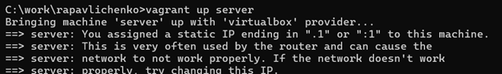

Выполнено подключение по SSH.

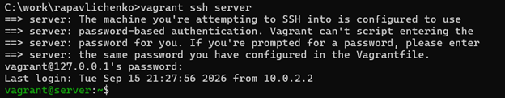

## Получение административных прав

Получены полномочия суперпользователя для настройки системных служб.

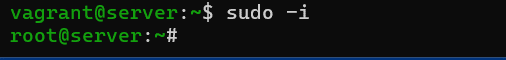

## Установка Kea DHCP

Установлен пакет DHCP-сервера Kea.

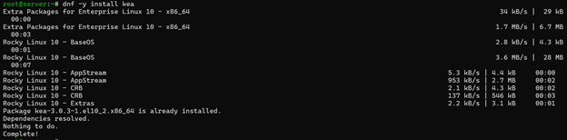

## Подготовка конфигурации

Создана резервная копия исходной конфигурации.

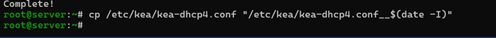

Настроены подсеть, пул адресов, DNS и параметры аренды.

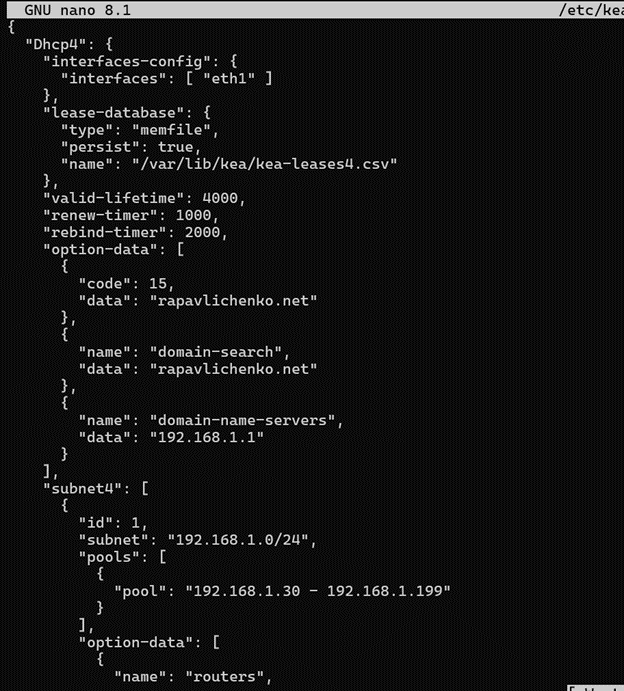

## Интерфейс и проверка конфигурации

Сервер привязан к интерфейсу `eth1`.

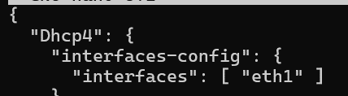

Файл проверен средствами Kea.

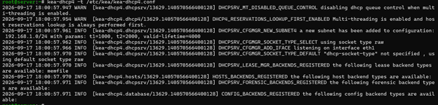

## Автоматический запуск Kea

Служба `kea-dhcp4` включена в автозагрузку.

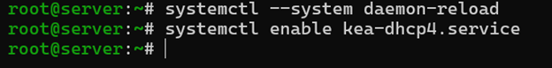

# Регистрация DHCP в DNS

## Записи прямой и обратной зон

Добавлена A-запись `dhcp`.

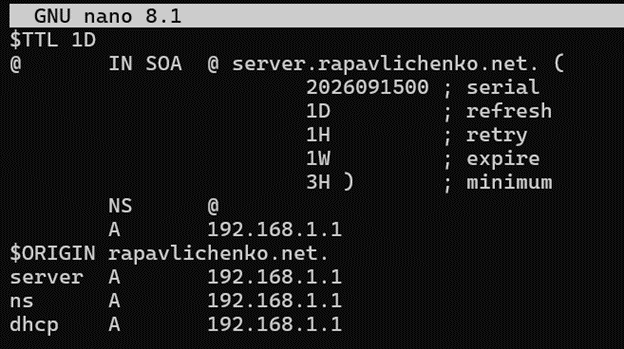

Добавлена PTR-запись DHCP-сервера.

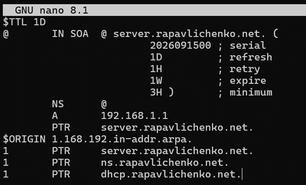

## Проверка имени DHCP-сервера

Имя `dhcp.rapavlichenko.net` разрешается в адрес `192.168.1.1`.

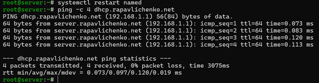

## Межсетевой экран и SELinux

В `firewalld` разрешена служба DHCP.

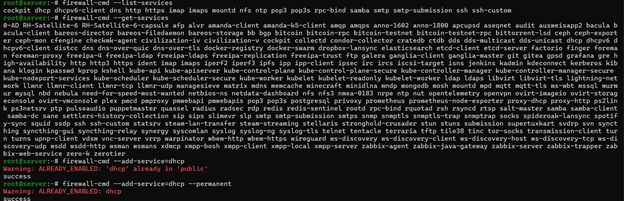

Восстановлены контексты SELinux.

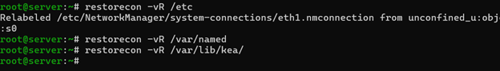

## Запуск и наблюдение за службой

Запущен просмотр системного журнала.

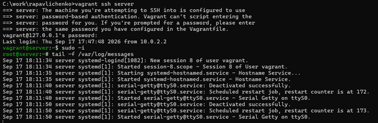

Запущена служба `kea-dhcp4`.

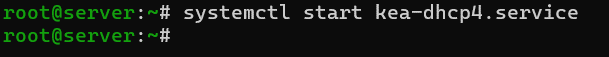

# Настройка клиента

## Маршрутизация клиентской машины

Сценарий задаёт шлюз `192.168.1.1` на интерфейсе `eth1` и отключает маршрут по умолчанию через `eth0`.

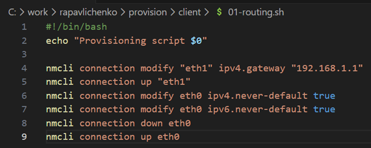

## Подключение сценария в Vagrant

В `Vagrantfile` добавлен provisioner `client routing`.

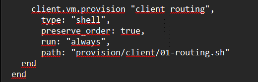

## Запуск клиента

Клиентская машина запущена с повторным применением настроек.

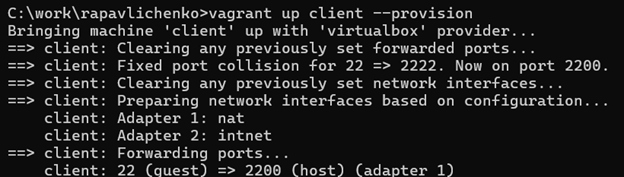

## Выдача адреса клиенту

Журнал Kea показывает запрос клиента, выделение адреса `192.168.1.30` и отправку DHCPACK.

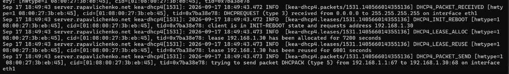

## Проверка интерфейсов

Интерфейс `eth1` получил адрес `192.168.1.30/24` из настроенного пула.

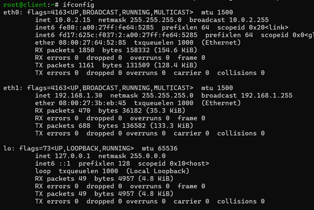

## Файл аренд Kea

В `/var/lib/kea/kea-leases4.csv` записана активная аренда адреса `192.168.1.30`.

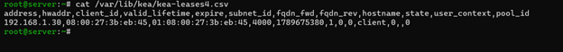

# Настройка DDNS

## Создание TSIG-ключа

Создан ключ `DHCP_UPDATER`.

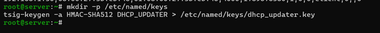

Проверено содержимое ключа.

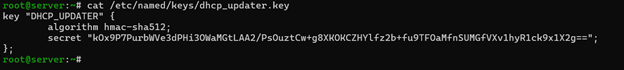

## Права и подключение ключа

Каталогу назначен владелец `named`.

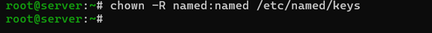

Ключ подключён в `named.conf`.

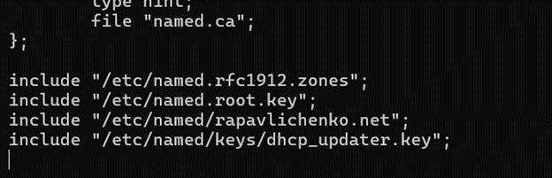

## Разрешение обновления зон

В прямой и обратной зонах разрешены обновления, подписанные ключом `DHCP_UPDATER`.

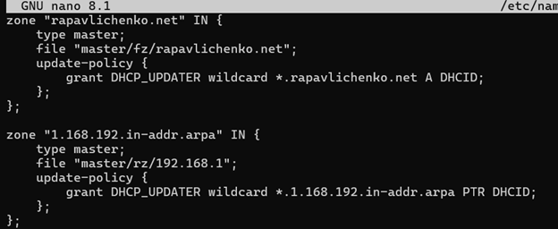

## Проверка BIND и подготовка Kea

Конфигурация BIND проверена, служба перезапущена, создан файл `/etc/kea/tsig-keys.json`.

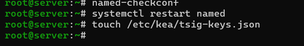

## Перенос TSIG-ключа

Ключ сохранён в формате JSON.

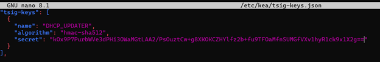

## Защита файла ключа

Файлу назначен владелец `kea`, права доступа ограничены значением `640`.

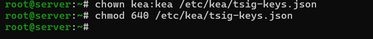